# Chapter 2 Examples Scatterplot

This document is derived from a .Rmd notebook entitled “BlandAltman_stutter_analysis_EFM_likeLTD.Rmd” last saved on 2021.05.30. That original notebook documented the code for performing a Bland-Altman analysis of two methods, and preparing graphs illustrating the results. For the purpose of this notebook, however, the code used for a scatterplot analysis is used to illustrate the creation of a scatterplot for Chapter 2 of the dissertation.

```r
knitr::opts_chunk$set(
    echo = TRUE,
    message = FALSE,
    warning = FALSE,
    results = TRUE
)
library(tidyverse)
```

```r
library(blandr) # required for calculating the Bland-Altman stats function, which calculates the difference, mean, and confidence intervals used in all BA plots
library(BlandAltmanLeh) # required for the customized BA function that I wrote (baPlotKPI), called from source below.
library(ggthemes) # required for the use of some plot themes, here 'stata' theme
library(ggExtra) # required for ggmarginal if used.
library(cowplot) # required for some plotting parameters; here panel_border and ggsave2
library(captioner) # required to caption figures and tables; the fig_nums and table_nums in this setup chunk is part of captioner
library(zeallot) # Used to unpack a list; needed for the Price-Fischer analysis
library(kableExtra)
library(ggpirate) # Used for creating pirateplots with more descriptive statistical information.
library(beanplot) # Used for creating beanplots; used here as a split bean

source("/Volumes/InmanDrive4/Dropbox/Dropbox/KPI/University_of_Dundee/Dissertation/Lab Notebooks/library.R")

#fig_nums <- captioner(prefix = "**Figure**")
# table_nums <- captioner(prefix = "**Table**")
```

```r
# Create dataframe and extract specific data for Bland Altman analysis: data for minor contributor E for this specific analysis

MT <- read.csv("/Volumes/InmanDrive4/Dropbox/Dropbox/KPI/University_of_Dundee/Dissertation/Lab Notebooks/Ch2_EDA_Examples/sample_data.csv")

KPITable(MT)
```

| Sample | Rep | lLR | Eff | Pr | St | NC | TC | TotDNA | amtDNA | C1 | C2 | C3 | C4 | D1 | D2 | D3 | D4 | CSF1PO | D13S317 | D16S539 | D18S51 | D19S433 | D21S11 | D2S1338 | D3S1358 | D5S818 | D7S820 | D8S1179 | FGA | … |
| --- | --- | --- | --- | --- | --- | --- | --- | --- | --- | --- | --- | --- | --- | --- | --- | --- | --- | --- | --- | --- | --- | --- | --- | --- | --- | --- | --- | --- | --- | --- |
| 11 | 1 | 7.6100000 | 3.96e-01 | likeLTD | Present | 2 | B | 500 | 250.00000 | C | B | NA | NA | 1 | 1 | NA | NA | -0.0091500 | 1.3200000 | 0.3300000 | 0.7850000 | 0.3170000 | 1.3100000 | 1.5200000 | 0.9610000 | 0.0220000 | -2.5100000 | 0.7870000 | 0.4990000 | … |
| 11 | 1 | 9.5000000 | 4.95e-01 | likeLTD | Absent | 2 | B | 500 | 250.00000 | C | B | NA | NA | 1 | 1 | NA | NA | 0.0522000 | 1.3600000 | 0.3420000 | 0.9640000 | 0.2540000 | 1.4200000 | 1.6400000 | 0.8870000 | 0.0444000 | -0.7150000 | 0.7080000 | 0.6390000 | … |
| 11 | 1 | 10.2990449 | 5.36e-01 | EFM | Present | 2 | B | 500 | 250.00000 | C | B | NA | NA | 1 | 1 | NA | NA | 0.1703553 | 1.4257603 | 0.5053757 | 0.9530704 | 0.2762059 | 1.5030714 | 1.6491788 | 0.7965640 | 0.0489095 | 0.3269739 | 0.5721727 | 0.6932531 | … |
| 11 | 1 | 10.7819912 | 5.62e-01 | EFM | Absent | 2 | B | 500 | 250.00000 | C | B | NA | NA | 1 | 1 | NA | NA | 0.1745291 | 1.4023237 | 0.4800626 | 0.9825948 | 0.2602748 | 1.5489793 | 1.6447963 | 0.8754455 | 0.0222894 | 0.3266562 | 0.5708905 | 0.7327175 | … |
| 12 | 2 | 9.6700000 | 5.04e-01 | likeLTD | Absent | 2 | B | 500 | 250.00000 | C | B | NA | NA | 1 | 1 | NA | NA | 0.1490000 | 1.4800000 | 0.4180000 | 1.0500000 | -0.1310000 | 1.6400000 | 1.9800000 | 0.7110000 | -0.1520000 | -0.8670000 | 0.8810000 | 0.6700000 | … |
| 12 | 2 | 10.7329697 | 5.59e-01 | EFM | Present | 2 | B | 500 | 250.00000 | C | B | NA | NA | 1 | 1 | NA | NA | 0.1780579 | 1.3751377 | 0.4872376 | 0.9789271 | 0.2660059 | 1.5697230 | 1.7017289 | 0.8809620 | 0.0436754 | 0.2960935 | 0.5251370 | 0.7035907 | … |
| 12 | 2 | 10.7320512 | 5.59e-01 | EFM | Absent | 2 | B | 500 | 250.00000 | C | B | NA | NA | 1 | 1 | NA | NA | 0.1834072 | 1.3676301 | 0.4748251 | 0.9873379 | 0.2652244 | 1.5781487 | 1.6777184 | 0.8670881 | 0.0368753 | 0.3222699 | 0.5291540 | 0.7331520 | … |
| 12 | 2 | 9.4900000 | 4.94e-01 | likeLTD | Present | 2 | B | 500 | 250.00000 | C | B | NA | NA | 1 | 1 | NA | NA | 0.2610000 | 1.5300000 | 0.4490000 | 0.9560000 | -0.1350000 | 1.6200000 | 2.0100000 | 0.8900000 | -0.3360000 | -1.5300000 | 1.0000000 | 0.6410000 | … |
| 13 | 3 | -1.0200000 | -5.31e-02 | likeLTD | Present | 2 | B | 500 | 250.00000 | C | B | NA | NA | 1 | 1 | NA | NA | -0.8230000 | -5.6700000 | 0.1490000 | 0.5820000 | -0.3800000 | 0.3500000 | 0.1420000 | 0.5220000 | -0.0703000 | -0.4210000 | 0.7690000 | 1.5700000 | … |
| 13 | 3 | -0.2223790 | -1.16e-02 | EFM | Present | 2 | B | 500 | 250.00000 | C | B | NA | NA | 1 | 1 | NA | NA | -0.4315599 | -6.6051701 | 0.0219969 | 1.0036537 | -0.3883275 | 0.5153422 | 0.6219035 | 0.8462755 | -0.3097217 | -0.0350691 | 0.9548920 | 1.3696764 | … |
| 13 | 3 | 9.4300000 | 4.91e-01 | likeLTD | Absent | 2 | B | 500 | 250.00000 | C | B | NA | NA | 1 | 1 | NA | NA | 0.1010000 | 1.3700000 | 0.4490000 | 1.1000000 | 0.2070000 | 1.4900000 | 1.7800000 | 0.8330000 | 0.0163000 | -0.9210000 | 0.7310000 | 0.5990000 | … |
| 13 | 3 | 10.8766401 | 5.66e-01 | EFM | Absent | 2 | B | 500 | 250.00000 | C | B | NA | NA | 1 | 1 | NA | NA | 0.1565094 | 1.3915982 | 0.4850831 | 1.0305180 | 0.2482198 | 1.5724980 | 1.6646954 | 0.9134254 | 0.0001690 | 0.3220004 | 0.6417566 | 0.7162886 | … |
| 14 | 4 | 9.9200000 | 5.17e-01 | likeLTD | Absent | 2 | B | 500 | 250.00000 | C | B | NA | NA | 1 | 1 | NA | NA | 0.1180000 | 1.4400000 | 0.4660000 | 0.9920000 | 0.4290000 | 1.2500000 | 1.8200000 | 1.0600000 | 0.2340000 | -0.9410000 | 0.7590000 | 0.6560000 | … |
| 14 | 4 | 10.7962428 | 5.62e-01 | EFM | Absent | 2 | B | 500 | 250.00000 | C | B | NA | NA | 1 | 1 | NA | NA | 0.1909866 | 1.4188795 | 0.5051050 | 0.9971163 | 0.2368788 | 1.7014254 | 1.7425236 | 0.8131987 | -0.1170997 | 0.3593705 | 0.5399845 | 0.7233383 | … |
| 14 | 4 | 10.8722377 | 5.66e-01 | EFM | Present | 2 | B | 500 | 250.00000 | C | B | NA | NA | 1 | 1 | NA | NA | 0.2307073 | 1.4567323 | 0.4936738 | 0.9987969 | 0.2127914 | 1.7486610 | 1.7589661 | 0.7647143 | -0.0830028 | 0.3552306 | 0.5301252 | 0.7289576 | … |
| 14 | 4 | 9.3700000 | 4.88e-01 | likeLTD | Present | 2 | B | 500 | 250.00000 | C | B | NA | NA | 1 | 1 | NA | NA | 0.3030000 | 1.2700000 | 0.4170000 | 0.8430000 | 0.5700000 | 0.9160000 | 1.6200000 | 1.0400000 | 0.4150000 | -1.2500000 | 0.5720000 | 0.7050000 | … |
| 15 | 5 | 15.0000000 | 7.81e-01 | likeLTD | Absent | 2 | B | 500 | 250.00000 | C | B | NA | NA | 1 | 1 | NA | NA | 0.5630000 | 2.1800000 | 0.7420000 | 1.1000000 | 0.5670000 | 2.0700000 | 1.8400000 | 0.8850000 | 0.2920000 | 0.6920000 | 0.9440000 | 0.6490000 | … |
| 15 | 5 | 14.9000000 | 7.76e-01 | likeLTD | Present | 2 | B | 500 | 250.00000 | C | B | NA | NA | 1 | 1 | NA | NA | 0.5840000 | 2.0700000 | 0.7200000 | 1.1400000 | 0.5470000 | 2.1800000 | 1.9700000 | 0.8400000 | 0.2850000 | 0.4590000 | 0.8640000 | 0.7990000 | … |
| 15 | 5 | 15.4287667 | 8.04e-01 | EFM | Present | 2 | B | 500 | 250.00000 | C | B | NA | NA | 1 | 1 | NA | NA | 0.7137060 | 2.3355632 | 0.6905554 | 1.0161608 | 0.5310700 | 2.2175187 | 2.1571340 | 0.8388532 | 0.2867191 | 0.7187508 | 0.8383651 | 0.6731909 | … |
| 15 | 5 | 15.0384936 | 7.83e-01 | EFM | Absent | 2 | B | 500 | 250.00000 | C | B | NA | NA | 1 | 1 | NA | NA | 0.7909925 | 2.3614725 | 0.7350793 | 0.8477020 | 0.5789193 | 2.0142285 | 2.0941726 | 0.9601778 | 0.2773861 | 0.6594445 | 0.8152872 | 0.4550697 | … |
| 41 | 1 | 9.7700000 | 5.09e-01 | likeLTD | Present | 2 | B | 500 | 166.66667 | C | B | NA | NA | 2 | 1 | NA | NA | 0.0725000 | 1.5800000 | 0.5790000 | 1.0100000 | 0.8680000 | 1.2700000 | 1.4500000 | 1.0600000 | -0.2350000 | -2.0800000 | 0.7430000 | 1.1400000 | … |
| 41 | 1 | 11.6532048 | 6.07e-01 | EFM | Present | 2 | B | 500 | 166.66667 | C | B | NA | NA | 2 | 1 | NA | NA | 0.1585412 | 1.7367721 | 0.7106997 | 0.9813968 | 0.4624572 | 1.6523355 | 1.7085413 | 0.5863271 | -0.0083444 | 0.2847984 | 0.4751563 | 1.0598813 | … |
| 41 | 1 | 10.8087081 | 5.63e-01 | EFM | Absent | 2 | B | 500 | 166.66667 | C | B | NA | NA | 2 | 1 | NA | NA | 0.1679670 | 1.3654450 | 0.4786519 | 0.9908588 | 0.2517563 | 1.5748133 | 1.6651907 | 0.8876964 | 0.0326729 | 0.3091922 | 0.6111943 | 0.7335335 | … |
| 41 | 1 | 9.4500000 | 4.92e-01 | likeLTD | Absent | 2 | B | 500 | 166.66667 | C | B | NA | NA | 2 | 1 | NA | NA | 0.2440000 | 1.3600000 | 0.4520000 | 1.0400000 | 0.1630000 | 1.4900000 | 1.5900000 | 0.9260000 | -0.0874000 | -0.9510000 | 0.5970000 | 0.6790000 | … |
| 42 | 2 | 9.9900000 | 5.20e-01 | likeLTD | Present | 2 | B | 500 | 166.66667 | C | B | NA | NA | 2 | 1 | NA | NA | 0.0154000 | 1.0400000 | 0.6780000 | 1.2400000 | 0.6590000 | 1.8500000 | 1.2000000 | 1.2300000 | 0.3490000 | -2.7900000 | 0.8180000 | 1.1200000 | … |
| 42 | 2 | 11.7271803 | 6.11e-01 | EFM | Present | 2 | B | 500 | 166.66667 | C | B | NA | NA | 2 | 1 | NA | NA | 0.1058177 | 1.4263102 | 0.5871102 | 0.9458797 | 0.8077969 | 1.9196611 | 1.4119572 | 0.6606900 | -0.0501373 | 0.4277772 | 0.5874675 | 0.6498248 | … |
| 42 | 2 | 11.4368207 | 5.96e-01 | EFM | Absent | 2 | B | 500 | 166.66667 | C | B | NA | NA | 2 | 1 | NA | NA | 0.1732114 | 1.5259080 | 0.3699674 | 0.8389298 | 0.6476923 | 1.9021947 | 1.3114757 | 0.6463527 | -0.1007465 | 0.5471795 | 0.5706150 | 0.9198113 | … |
| 42 | 2 | 11.8000000 | 6.15e-01 | likeLTD | Absent | 2 | B | 500 | 166.66667 | C | B | NA | NA | 2 | 1 | NA | NA | 0.2410000 | 1.4000000 | 0.4280000 | 1.0900000 | 0.7870000 | 1.9600000 | 1.3600000 | 0.9710000 | 0.0653000 | -0.7060000 | 0.8280000 | 0.9860000 | … |
| 43 | 3 | 11.7000000 | 6.09e-01 | likeLTD | Present | 2 | B | 500 | 166.66667 | C | B | NA | NA | 2 | 1 | NA | NA | -0.4010000 | 2.1600000 | 0.6760000 | 1.3300000 | 0.6550000 | 2.2200000 | 1.7800000 | 1.1500000 | 0.1860000 | -3.3400000 | 0.8970000 | 1.2700000 | … |
| 43 | 3 | 14.3000000 | 7.45e-01 | likeLTD | Absent | 2 | B | 500 | 166.66667 | C | B | NA | NA | 2 | 1 | NA | NA | -0.2180000 | 2.3900000 | 0.4650000 | 1.1800000 | 0.7370000 | 2.4600000 | 1.8900000 | 1.1500000 | -0.2580000 | -0.4570000 | 0.9880000 | 1.2900000 | … |

[output cut: 490 more lines]

#### Calculate the correlation coefficients

I want to find the correlation between and within programs and stutter, by total input DNA, and then insert them into the scatterplots:

EFM_Absent : likeLTD_Absent for 500 or 100 ng

EFM_Present : likeLTD_Present for 500 or 100 ng

EFM_Absent : EFM_Present for 500 or 100 ng

likeLTD_Absent : likeLTD_Present for 500 or 100 ng

The approach will be to first create tables subsetted by TotDNA (total input DNA) and Program (which creates two datatables), merging the two data tables into one, and then using the ‘cor’ function on the entire merged table to get a matrix of Pearson correlation values for pairs of variables.

```r
#
smallMT <- MT[,-c(2,4,7,8,10:33)] #Create a smaller datatable without unnecessary columns

EFM500 <- subset(smallMT, Pr == "EFM" & TotDNA == 500) |>
  select(1,2,4)

EFM500 <- EFM500 |>
  pivot_wider(names_from = St, values_from = lLR)

likeLTD500 <- subset(smallMT, Pr == "likeLTD" & TotDNA == 500) |>
    select(1,2,4)

likeLTD500 <- likeLTD500 |>
  pivot_wider(names_from = St, values_from = lLR)

Pr500 <- likeLTD500 |>
  inner_join(EFM500, by = "Sample") |>
  rename(l_Present = "Present.x", l_Absent = "Absent.x", E_Present = "Present.y", E_Absent = "Absent.y")

C500P <- as.data.frame(cor(Pr500)) #The cor(dataframe) command creates a matrix containing the correlation coefficients calculated for  all combinations of variables. From this table one can abstract the appropriate one to insert into the graphs later.

EFM500St <- signif(C500P[5,4], 3)
like500St <- signif(C500P[3,2], 3)
```

```r
#
smallMT <- MT[,-c(2,4,7,8,10:33)] # Create a smaller table without unnecessary columns

EFM100 <- subset(smallMT, Pr == "EFM" & TotDNA == 100) |>
  select(1,2,4)

EFM100 <- EFM100 |>
  pivot_wider(names_from = St, values_from = lLR)

likeLTD100 <- subset(smallMT, Pr == "likeLTD" & TotDNA == 100) |>
    select(1,2,4)

likeLTD100 <- likeLTD100 |>
  pivot_wider(names_from = St, values_from = lLR)

Pr100 <- likeLTD100 |>
  inner_join(EFM100, by = "Sample") |>
  rename(l_Present = "Present.x", l_Absent = "Absent.x", E_Present = "Present.y", E_Absent = "Absent.y")

C100P <- as.data.frame(cor(Pr100))
```

#### Create dataframes for scatterplot

```r
# Subset and widen dataframe for creating graphs later in script.
# Keep only Sample, lLR, Pr, St, and amtDNA
widerMT <- MT[,-c(2,4,7:8,10:33)] |>
  pivot_wider(names_from = St, values_from = lLR)

widerMT$TotDNA <- as.factor(widerMT$TotDNA)
widerMT$Pr <- as.factor(widerMT$Pr)

KPITable(widerMT)
```

| Sample | Pr | TotDNA | Present | Absent |
| --- | --- | --- | --- | --- |
| 11 | likeLTD | 500 | 7.6100000 | 9.5000000 |
| 11 | EFM | 500 | 10.2990449 | 10.7819912 |
| 12 | likeLTD | 500 | 9.4900000 | 9.6700000 |
| 12 | EFM | 500 | 10.7329697 | 10.7320512 |
| 13 | likeLTD | 500 | -1.0200000 | 9.4300000 |
| 13 | EFM | 500 | -0.2223790 | 10.8766401 |
| 14 | likeLTD | 500 | 9.3700000 | 9.9200000 |
| 14 | EFM | 500 | 10.8722377 | 10.7962428 |
| 15 | likeLTD | 500 | 14.9000000 | 15.0000000 |
| 15 | EFM | 500 | 15.4287667 | 15.0384936 |
| 41 | likeLTD | 500 | 9.7700000 | 9.4500000 |
| 41 | EFM | 500 | 11.6532048 | 10.8087081 |
| 42 | likeLTD | 500 | 9.9900000 | 11.8000000 |
| 42 | EFM | 500 | 11.7271803 | 11.4368207 |
| 43 | likeLTD | 500 | 11.7000000 | 14.3000000 |
| 43 | EFM | 500 | 13.9045558 | 12.8259218 |
| 44 | likeLTD | 500 | 14.4000000 | 15.2000000 |
| 44 | EFM | 500 | 14.0674651 | 13.0366112 |
| 45 | likeLTD | 500 | 10.9000000 | 12.0000000 |
| 45 | EFM | 500 | 11.8905926 | 11.6600047 |
| 71 | likeLTD | 500 | 13.9000000 | 14.1000000 |
| 71 | EFM | 500 | 15.1648061 | 15.2099923 |
| 72 | likeLTD | 500 | 13.1000000 | 14.7000000 |
| 72 | EFM | 500 | 14.7465008 | 13.7851762 |
| 73 | EFM | 500 | 13.0717835 | 12.9463534 |
| 73 | likeLTD | 500 | 13.1000000 | 13.5000000 |
| 74 | EFM | 500 | 12.5292366 | 14.3309373 |
| 74 | likeLTD | 500 | 8.1900000 | 11.4000000 |
| 75 | likeLTD | 500 | 13.6000000 | 14.3000000 |
| 75 | EFM | 500 | 14.3940791 | 14.6511618 |

[output cut: 230 more lines]

#### Scatterplot of stutter present vs. stutter absent for all samples and both programs

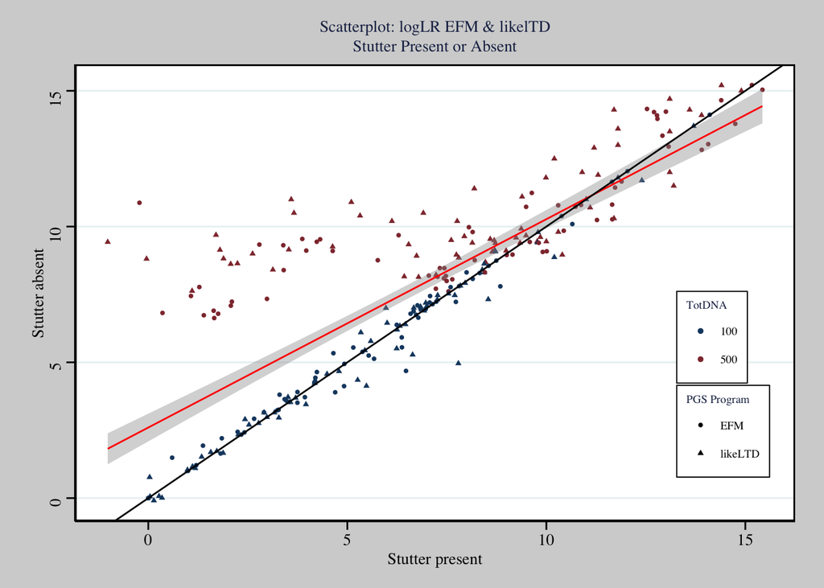

```r
 St_Pr_scatter <- ggplot(widerMT, aes(x = Present, y = Absent)) +
    geom_point(aes(shape = Pr, color = TotDNA), size = 1) +
      scale_shape_manual(values = c(5, 17)) +
      scale_color_manual(values = c( "#723957","#723959")) +
      scale_shape_discrete(name = "PGS Program") +
      scale_color_discrete(name = "Total input DNA") +
    geom_smooth(method = lm, se = TRUE, color = "red", size = .5, fullrange = TRUE) +
    geom_abline() +
    labs(title = "Scatterplot: logLR EFM & likelTD\nStutter Present or Absent", x = "Stutter present", y = "Stutter absent") +
    theme_stata(base_family = "serif") +
    panel_border(color = "black") +
    scale_color_stata() +
    theme(plot.title = element_text(size = 10, hjust = 0.5),
          plot.background = element_rect(fill = "lightgray"),
          legend.title = element_text(size = 7),
          legend.title.align = 0,
          legend.text = element_text(size = 7),
          legend.position = c(.9,.3)) # Sets legend inside of plot area

ggsave2("Stutter_Program_scatter.pdf", width = 7.3, height = 6)

St_Pr_scatter
```

#### Separate the total input DNA into separate scatterplots, adding correlation coefficients.

```r
 anno <- data.frame(xstar = c(4, 4), ystar = c(13.5, 13.5),
                   lab = c(EFM500St, like500St),
                   TotDNA = c(100, 500))
```

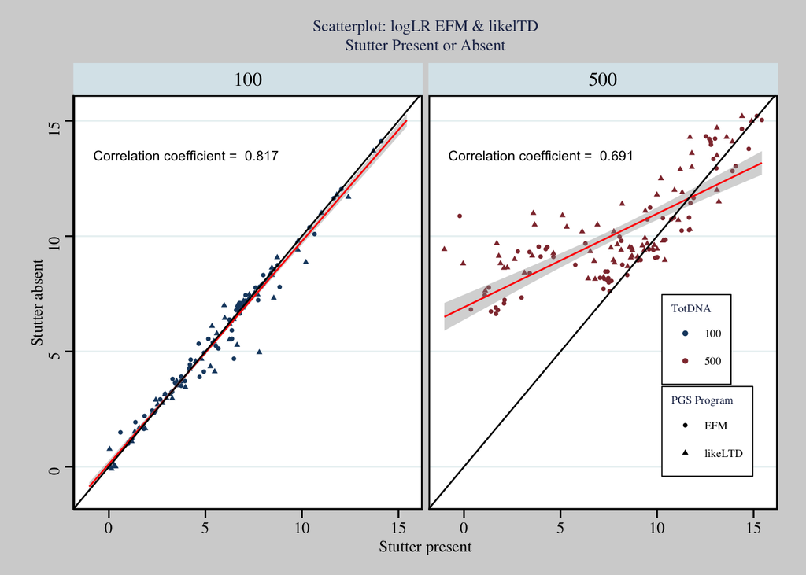

```r
 St_Pr_scatter_facet <- ggplot(widerMT, aes(x = Present, y = Absent)) +
    geom_point(aes(shape = Pr, color = TotDNA), size = 1) +
      scale_shape_manual(values = c(5, 17)) +
      scale_color_manual(values = c( "#723957","#723959")) +
      scale_shape_discrete(name = "PGS Program") +
      scale_color_discrete(name = "Total input DNA") +
    geom_text(data = anno, aes(x = xstar, y = ystar, label = paste("Correlation coefficient = ",lab)), size = 3) +
    facet_wrap(~ TotDNA, scales = "fixed") +
      #annotate("text", x = 4, y = 13.5, label = paste("Correlation Coefficient = ", EFM500St), size = 3) +
    geom_smooth(method = lm, se = TRUE, color = "red", size = .5, fullrange = TRUE) +
    geom_abline() +
    labs(title = "Scatterplot: logLR EFM & likelTD\nStutter Present or Absent", x = "Stutter present", y = "Stutter absent") +
    theme_stata(base_family = "serif") +
    panel_border(color = "black") +
    scale_color_stata() +
    theme(plot.title = element_text(size = 10, hjust = 0.5),
          plot.background = element_rect(fill = "lightgray"),
          legend.title = element_text(size = 7),
          legend.title.align = 0,
          legend.text = element_text(size = 7),
          legend.position = c(.9,.3)) # Sets legend inside of plot area

ggsave2("Stutter_Program_facet_scatter.pdf", width = 7.3, height = 6)
St_Pr_scatter_facet
```